# Relatório

Eyes Analytic

2024-11-24

# Introdução

Este relatório apresenta uma análise dos dados coletados sobre o uso de recursos de servidores, tráfego de rede, alertas de segurança e outros parâmetros do sistema. A seguir, são apresentadas as consultas realizadas e as visualizações geradas a partir dos dados.

## Uso de Recursos

### 1.1 Consulta de Uso de CPU e RAM

**Objetivo:** Verificar o uso médio e o pico de CPU e RAM ao longo do tempo.

**Visualização:** O gráfico de dispersão exibe o uso médio de CPU e RAM ao longo do tempo.

[output not shown]

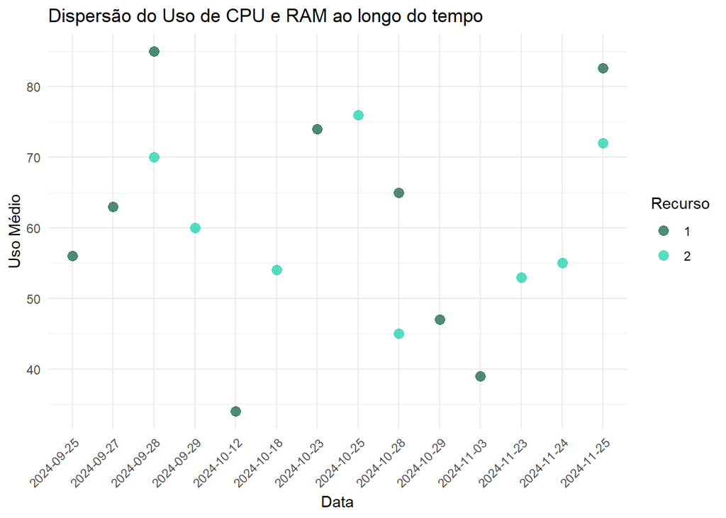

### 1.2 Comparativo de Uso por Máquina

**Objetivo:** Comparar o uso de CPU e RAM entre diferentes máquinas.

**Visualização:** Um gráfico de barras compara o uso médio de CPU e RAM em cada máquina.

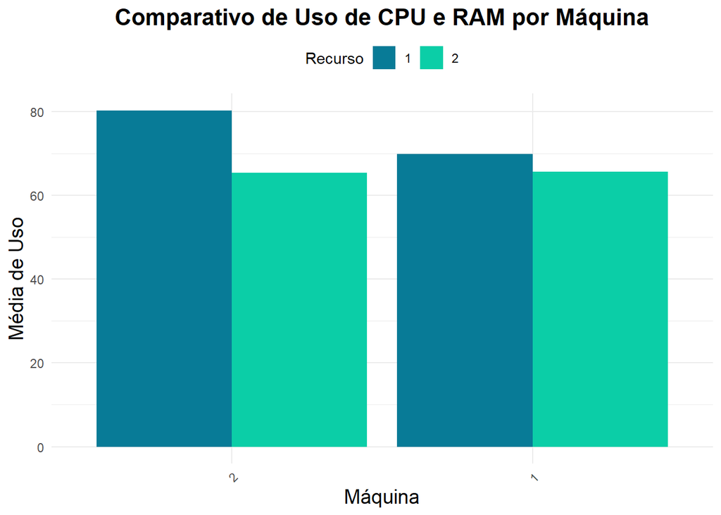

## Análise de Rede

### 2.1 Desempenho de Tráfego de Rede

````
```
## Warning: Using `size` aesthetic for lines was deprecated in ggplot2 3.4.0.
## ℹ Please use `linewidth` instead.
```



```
## Média de Download: 0.00 Mb
```

```
## Média de Upload: 0.00 Mb
```

```
## Tamanho médio de pacotes: 0.0010260614 Kb
```
````

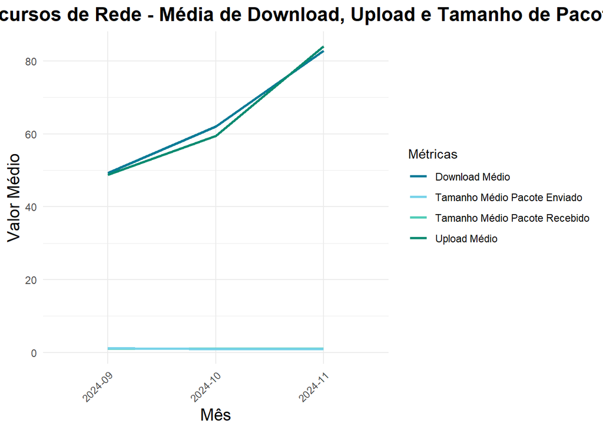

## Análise de Segurança

### 3.1 Uso Excessivo de CPU e RAM

**Objetivo:** Identificar períodos com uso excessivo de CPU e RAM.

**Visualização:** O gráfico de barras exibe quando o uso de CPU e RAM ultrapassou o limite, destacando os períodos críticos.

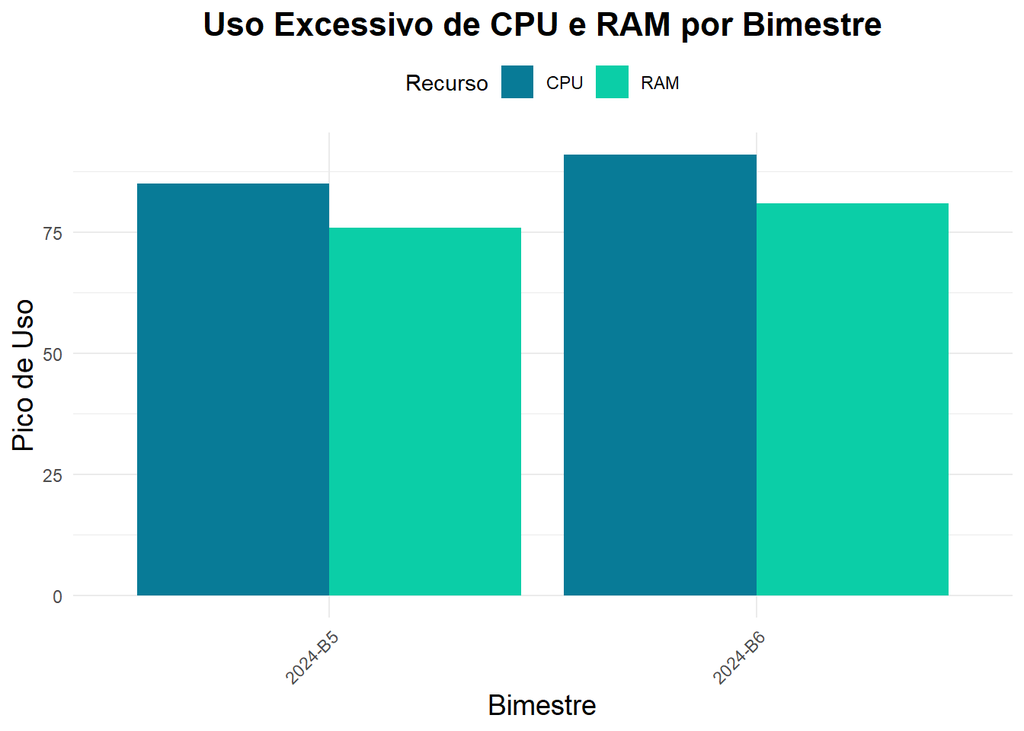

## Análise de Segurança

### 3.2 Priorização dos Alertas

**Objetivo:**Classificar os alertas de acordo com sua gravidade (alto, médio, baixo).

**Gravidade dos alertas:**Classifica os alertas com base no impacto do recurso monitorado, ajudando a priorizar as ações.

**Visualização:**O gráfico de barras mostra a quantidade de alertas em cada nível de gravidade, permitindo que os problemas mais urgentes sejam resolvidos primeiro.

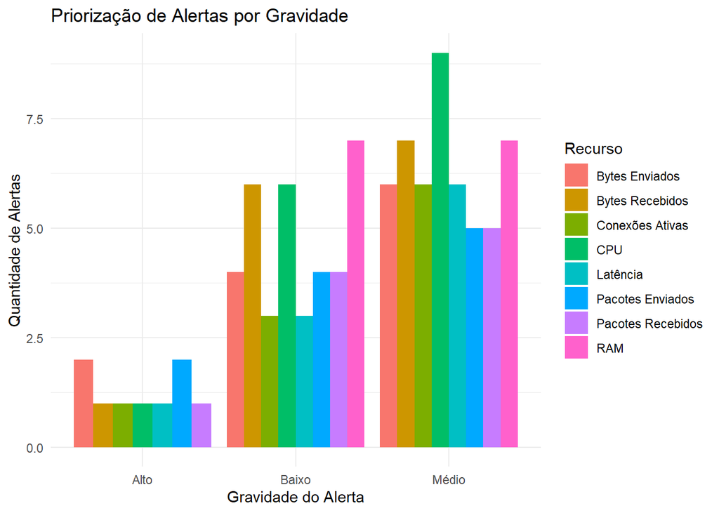

## Conclusões

Com base nas análises realizadas, foi possível identificar padrões de uso de recursos, possíveis gargalos e momentos críticos de tráfego de rede. Essas informações são essenciais para otimizar o desempenho dos servidores e garantir a segurança do ambiente de TI.

### Ranking de Componentes com Mais Alertas

**Objetivo:** Identificar os componentes do sistema (como CPU, RAM, disco, etc.) que geraram mais alertas.

**Análise:** A consulta SQL conta o total de alertas para cada tipo de componente, classificando-os do mais crítico para o menos crítico.

**Visualização:**O gráfico de barras mostra o número total de alertas para cada componente. As barras são ordenadas em ordem decrescente, com os componentes com mais alertas à esquerda.

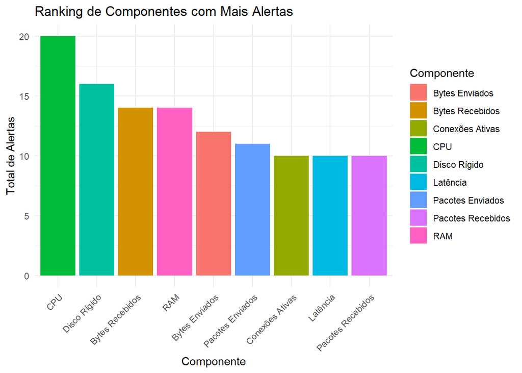